# Rise of Rayo Vallecano

All who follows football has heard of the two big clubs of Madrid, Real Madrid CF and Atletico Madrid and why not they are historically they rank among top clubs not only in Spain but all of Europe. Madrid as a city has most number of european champions in terms of football thanks to the exploits of the Real Madrid and Atletico Madrid have made it to three finals albeit lost in all of them. There is a huge gap in between two historic Madrid clubs and the third one in Rayo Vallecano. Founded in 1924, Rayo Vallecano abbreviated as Rayo play at their modest 14,000 seater stadium, historically they played their majority of football in Segunda Divison (Second League in Spanish Football Pyramid). But this season they find themselves in competition for European places in La Liga for various reasons.

[figure not shown]

1. Return of El Tigre

Radamel Falcao or ‘El Tigre’ as he is affectionately called returned to La Liga from Galatasaray by signing for Rayo. Former Atletico Madrid star now aged 35 is showing so signs of slowing out as he is carrying Rayo’s attack along with 29 year old Alvaro Garcia his addition to the squad is one of the major reasons behind Rayo’s current position

```r
rayo <- understat_team_players_stats("https://understat.com/team/Rayo_Vallecano/2021")

rayo %>%
  select(player_name, time, goals, assists) %>%
  head(3)
```

```
##     player_name time goals assists
## 1        Falcao  358     5       0
## 2 Álvaro García 1479     5       2
## 3   Óscar Trejo 1114     3       8
```

2. Attacking Style of Play

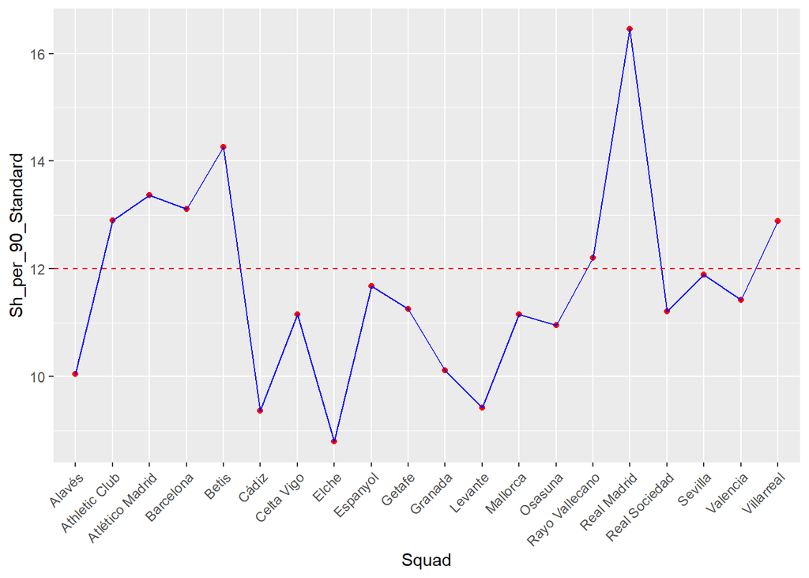

```r
laliga_2021_shooting <- get_season_team_stats(country = "ESP", gender = "M", season_end_year = "2022", tier = "1st", stat_type = "shooting")

laliga_2021_shooting %>%
  head(20) %>%
  arrange(Sh_per_90_Standard) %>%
  ggplot(aes(x = Squad, y = Sh_per_90_Standard)) + geom_point(color = "red") + geom_line(group = 1, color = "blue") + theme(axis.text.x = element_text(angle = 45, vjust = 1, hjust = 1)) + geom_hline(yintercept = 12, linetype = "dashed", color = "red")
```

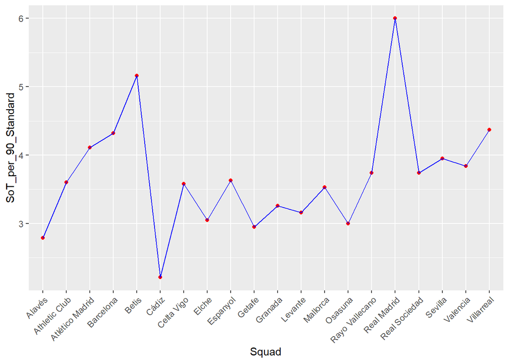

```r
laliga_2021_shooting %>%
  head(20) %>%
  arrange(SoT_per_90_Standard) %>%
  ggplot(aes(x = Squad, y = SoT_per_90_Standard)) + geom_point(color = "red") + geom_line(group = 1, color = "blue") + theme(axis.text.x = element_text(angle = 45, vjust = 1, hjust = 1))
```

With 30 points already in this season’s tally, Rayo Vallecano one of the contenders of relgation know find themselves fighting for european places whether they can maintain momentum this season and in future would be interesting to see in future.